# Regression

## Hedgerows and partridges

Hedgerows are the main nesting habitat of the grey partridge (*Perdix perdix*). A survey was carried out to establish whether the abundance of hedgerows in agricultural land had an effect on the abundance of grey partridge. From an area of agricultural land covering several farms, twelve plots were selected which had land uses as similar as possible but differed in the density of hedgerows (km hedgerow per km2). Plots were deliberately selected to cover a wide range of hedgerow densities. The total hedgerow lengths, and exact plot areas, were measured by use of large scale maps. The density of partridges was established by visiting all fields in a study plot once immediately after dawn and once just before dusk, when partridges are feeding and therefore most likely to be seen. Counts of birds observed were made on each visit and the dawn and dusk data were averaged to give a value for partridge abundance for each study plot.

The data are stored in a CSV file PARTRIDG.CSV. Take note: this is a different data set than the one used in the ‘Regression diagnostics’ chapter. The density of hedgerows (km per km2) is in the `Hedgerow` variable and the density of partridges (no. per km2) is in the `Partridge` variable.

### First steps

As always start by loading the necessary packages.

```r
library(readr)
library(dplyr)
library(ggplot2)
```

Either create an RStudio project or set your working directory to the folder containing the data set that you want to work with. Then read the data into R (remember to assign it a name):

```r
partridge <- read_csv("PARTRIDG.CSV")
```

Start by having a quick look at the data. How many variables are there? Is the format appropriate for a regression (i.e. are the dependent and independent variables on an interval or ratio scale)?

```r
glimpse(partridge)
```

```
## Rows: 12
## Columns: 2
## $ Hedgerow  <dbl> 8.4, 9.1, 14.0, 21.9, 27.2, 32.5, 30.1, 15.9, 27.1, 34.8, 1…
## $ Partridge <dbl> 1.3, 8.2, 1.2, 12.7, 21.9, 19.4, 26.4, 8.4, 7.1, 25.2, 0.0,…
```

Remember that regression also requires that the residuals are independent (i.e. that the value of one residual does not depend on the value of other residuals) and that there is negligible measurement error in the values of $x$. These two assumptions should have been considered earlier, as part of the experimental design.

### Visualising the data

Next make a quick plot of the data. Remember that the independent and dependent variables should go on the $x$ and $y$ axes respectively. This plot allows for crude checks of whether there is a linear relationship between the two variables and whether the variance is constant (i.e. that the scatter in $y$ neither increases nor decreases substantially with increasing values of $x$).

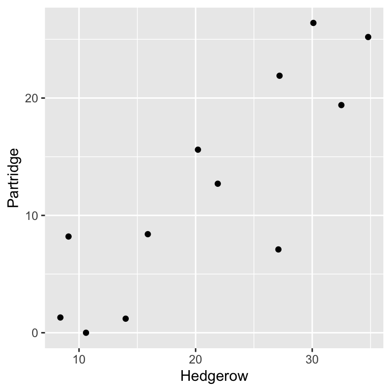

```r
ggplot(partridge, aes(x=Hedgerow, y = Partridge)) +
  geom_point()
```

Here, there does appear to be a linear relationship and there is no obvious violation of the constant variance assumption. We will come back to these assumptions using regression diagnostics, after fitting the model.

### Fitting the model

Fit the model using the `lm` function, which takes a formula and a data frame containing the variables in the formula as its two arguments. Remember that in the formula the dependent and independent variables go on the left and right side of the `~` respectively.

```r
partridge_model <- lm(Partridge ~ Hedgerow, data = partridge)
```

### Check the model diagnostics

Check the model diagnostics **before** looking at the statistical output. This is important. There is no point worrying about *p*-values until you’re convinced the assumptions of a model have been met.

First plot the residuals against the fitted values. This allows the assumption that the relationship between the independent (hedgerow density) and dependent (partridge density) is linear to be checked. Look for patterns (such as u- or hump-shapes) that may suggest that there is a pattern between the variables that is not accommodated by the fitted model.

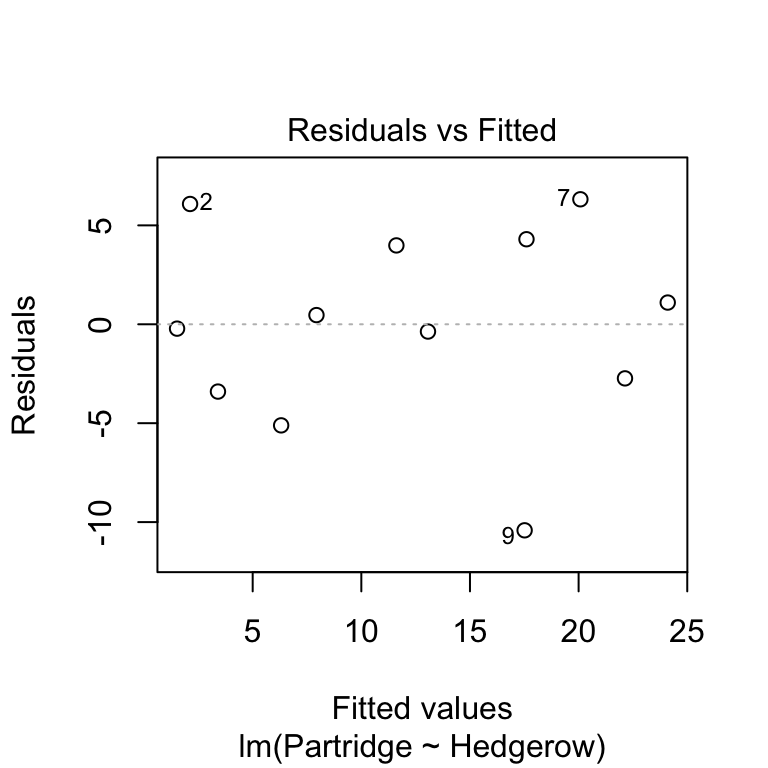

```r
plot(partridge_model, add.smooth = FALSE, which = 1)
```

There are no obvious patterns in this plot, suggesting that the linear relationship assumption is met.

Next check the normality assumption using a normal probability plot. Here, if the residuals are normally distributed they will be positioned on the dashed line of best fit. Note that we don’t expect to see a perfect relationship, but the majority of the points should be close to the line.

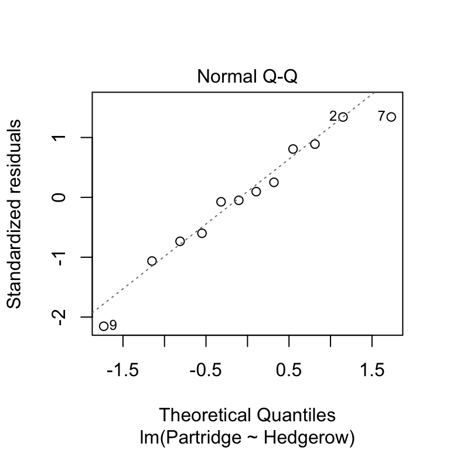

```r
plot(partridge_model, which = 2)
```

In this example nearly all of the points are very close to the line, suggesting that the residuals are drawn from a normal distribution.

Finally, check the constant variance assumption using a scale-location plot. Ideally there should be a flat relationship between the transformed residuals and the fitted values. If the residuals either increase or decrease as the fitted values increase then the constant variance assumption is violated.

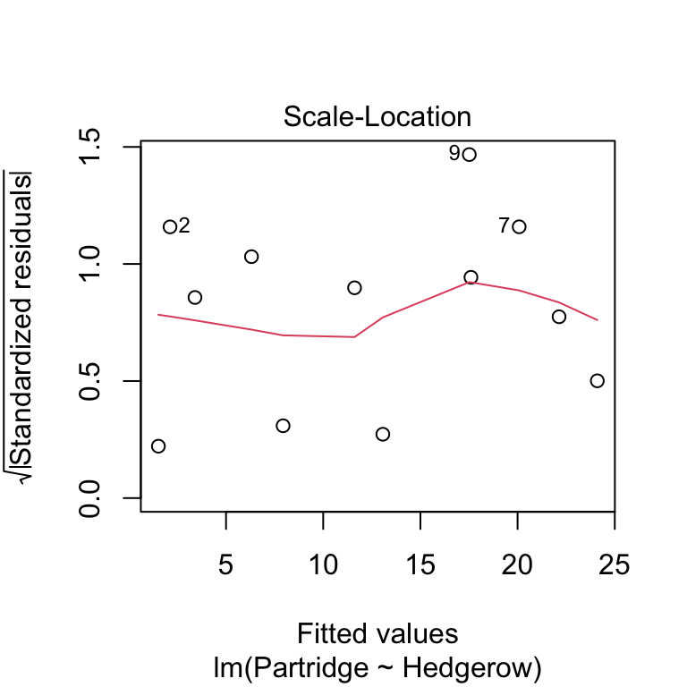

```r
plot(partridge_model, which = 3)
```

There does not appear to be a trend here (i.e the residuals do not increase or decrease as the fitted values increase).

Remember that regression is fairly robust to small violations in these assumptions. If there are large violations transforming the data may help e.g. using logs, square roots (if count data), arcsine square roots (if percentages or proportions), or squares. After fitting the model to the transformed data the model diagnostics must be repeated to check whether or not the assumptions are now met.

### Statistical output

If, and only if, the model assumptions were not violated, it is now time to look at the model output. An *F*-test can be used to determine whether the slope of the fitted model is significantly different to zero. This is carried out using the `anova` function, which takes the name of the fitted model as its only argument.

```r
anova(partridge_model)
```

```
## Analysis of Variance Table
##
## Response: Partridge
##           Df Sum Sq Mean Sq F value    Pr(>F)
## Hedgerow   1 706.87  706.87  26.521 0.0004315 ***
## Residuals 10 266.53   26.65
## ---
## Signif. codes:  0 '***' 0.001 '**' 0.01 '*' 0.05 '.' 0.1 ' ' 1
```

The table summarises the different parts of the *F*-test calculations: `Df` – degrees of freedom, `Sum Sq` – the sum of squares, `Mean Sq` – the mean square, `F value` – the *F*-statistic, `Pr(>F)` – the p-value. The *F*-statistic is the key term; larger values of the *F* statistic indicate a stronger relationship between the independent and dependent variables. A p-value of less than 0.05 indicates the result is statistically significant. Also make a note of the degrees of freedom, as these should be included in the results.

In this example, the slope is significantly different to zero, which suggests that there is a significant effect of hedgerow density on partridge density.

### Extracting a bit more information from the model (optional)

Next use the `summary` function to extract some more information about the fitted model. As with the `anova` function this takes the name of the fitted model as its one argument.

```r
summary(partridge_model)
```

```
##
## Call:
## lm(formula = Partridge ~ Hedgerow, data = partridge)
##
## Residuals:
##      Min       1Q   Median       3Q      Max
## -10.4153  -2.9011   0.1224   4.0648   6.3186
##
## Coefficients:
##             Estimate Std. Error t value Pr(>|t|)
## (Intercept)  -5.6650     3.7905  -1.495 0.165904
## Hedgerow      0.8554     0.1661   5.150 0.000432 ***
## ---
## Signif. codes:  0 '***' 0.001 '**' 0.01 '*' 0.05 '.' 0.1 ' ' 1
##
## Residual standard error: 5.163 on 10 degrees of freedom
## Multiple R-squared:  0.7262, Adjusted R-squared:  0.6988
## F-statistic: 26.52 on 1 and 10 DF,  p-value: 0.0004315
```

The first couple of lines here give the formula for the model. The next few lines gives some properties of the residuals, which can be ignored. The next few lines gives the coefficients table. The first (`(Intercept)`) and second (`Hedgerow`) rows relate to the intercept and slope of the fitted line, respectively. The columns (`Estimate`, `Std. Error`, `t value`, and `Pr(>|t|)`) show the estimates of each coefficient, standard error associated with each coefficient, the corresponding t-statistics, and the p-values respectively. The estimated intercept and slope coefficients are the useful bit here. These allow us to make predictions, i.e. for a given a value of hedgerow density, we can predict how many partidges we expect to find.

The `Multiple-R-squared` value is also useful. This shows the proportion of variance in the dependent variable that is explained by the independent variable. As it is a proportion it is always between 0 and 1, with values of 0 or 1 indicating that none or all of the variation has been explained by the model, respectively. The value of 0.73 here is reasonably high, but there is still some unexplained variation.

Be careful with the *p*-values in the summary output. Sometimes these are useful, sometimes thay are not. In this example, the summary output indicates that, the slope, but not the intercept, is significantly different to zero. In the case of a simple linear regression the *p*-value for the slope term produced by `summary` is the same as that produced by the `anova` function above. The same equivalence is not seen with other kinds of models (e.g. one way Analysis of Variance). In general, you should play it safe and use `anova` (not `summary`!) to assess significance of model terms.

### Presenting the results

The results could be summarised in text as follows:

> There is a significant positive relationship between the density of hedgerows and partridges ($y = -5.7 + 0.86x$; F=26.5, d.f=1,10, *p*<0.001).

The degrees of freedom (d.f) should be reported as the slope degrees of freedom first then the error degrees of freedom.

Often the results are easier to interpret as a figure, showing the raw data and the fitted regression line. To do this first create a data frame with values for the independent variable over the observed range. These are the values over which the dependent variable will be predicted. The `seq` function can be used to create a sequence of (25) evenly spaced numbers from the minimum (8.4) to the maximum (34.8) value of the independent variable (hedgerow density in this case) from the raw data.

```r
pred.data <- data.frame(Hedgerow = seq(8.4, 34.8, length.out = 25))
```

Next use the `predict` function, within `mutate`, to predict the values of the dependent variable (partridge density) for each value of the independent variable, using the fitted model.

```r
pred.data <- mutate(pred.data, Partridge = predict(partridge_model, pred.data))
```

Finally, plot the raw data and the fitted line.

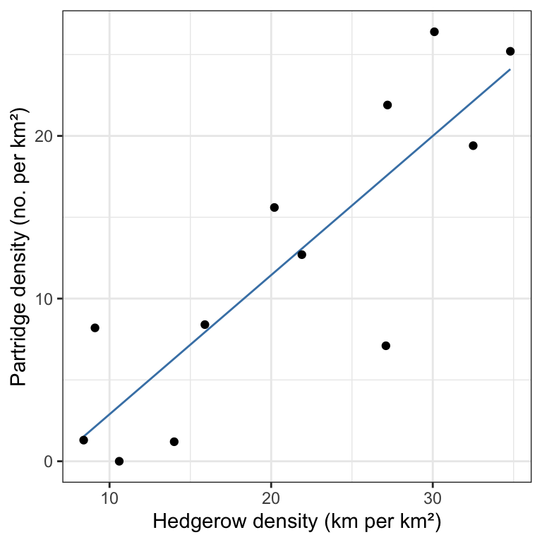

```r
ggplot(pred.data, aes(x = Hedgerow, y = Partridge)) +
  ## Plot the fitted line
  geom_line(colour = "steelblue") +
  ## Add the points to the plot using the raw data
  geom_point(data = partridge) +
  ## Change the axis labels
  labs(x = "Hedgerow density (km per km²)", y = "Partridge density (no. per km²)") +
  ## Change the theme (sets background colour etc)
  theme_bw()
```